# Class Project

Nate Smullen, Alex Lindquist, Wynter Malone

2022-11-29

```r
library(dplyr)
library(tidyverse)
library(here)
library(janitor)
library(gbfs)
library(maps)
```

Do bikes ever completely run out at a station in the Capital Bikeshare?

#Getting the Data Using get_station_status() from the gbfs package, we got the status of each station once per minute during a high-traffic time when the bikes are more likely to run out.

```r
#Code that runs about every minute to grab station info on chosen variables.

#Replace file path to local machine path
filename= "C:/Users/vvexi/OneDrive/Documents/R_Scripts/DS241-Class-Project/data_raw/station_info.csv"

headers = data.frame("station_id", "num_bikes_available",
                     "num_ebikes_available", "last_updated", "total_bikes_available")
write.table(headers, file = filename, row.names = FALSE,
            col.names = FALSE, sep = ",")

i = 0
while(i < 60) {
  print(paste("its been", i, "minutes since this started, give or take a bit"))
  i = i + 1

  station_status <- get_station_status("cabi") %>%
            select(station_id, num_bikes_available,
                   num_ebikes_available, last_updated) %>%
        mutate(total_bikes_available = num_bikes_available
            + num_ebikes_available)


write.table(station_status, file=filename, append=TRUE, row.names = FALSE,
            col.names = FALSE, sep = ",")


  Sys.sleep(60)
}
```

We then read the csv we wrote to into a data frame.

```r
thisfile=here("data_raw" ,"station_info.csv")

df_stations = read_csv(thisfile) %>% clean_names()
```

#Analysis

We wanted to look specifically at stations that were the closest to running out of bikes, so we wrote code to take the 10 stations that had the lowest average amount of bike available during the hour.

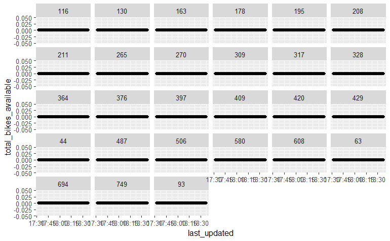

```r
avg_bikes <- df_stations %>% group_by(station_id) %>% summarize(mean(total_bikes_available)) %>% clean_names() %>% slice_min(order_by = mean_total_bikes_available, n=10)

df_stations %>% filter(station_id %in% avg_bikes$station_id) %>% ggplot(aes(last_updated, total_bikes_available)) + geom_line() + geom_point() + facet_wrap(~station_id)
```

Looking at this graph, we noticed there are a significant number of stations with no bikes available. This could be because those stations are no longer active or there is an issue with the data. To look at some other data, we will run it again, filtering so that the average number of bikes is greater than 0. This will show us if some stations had bikes, then ran out.

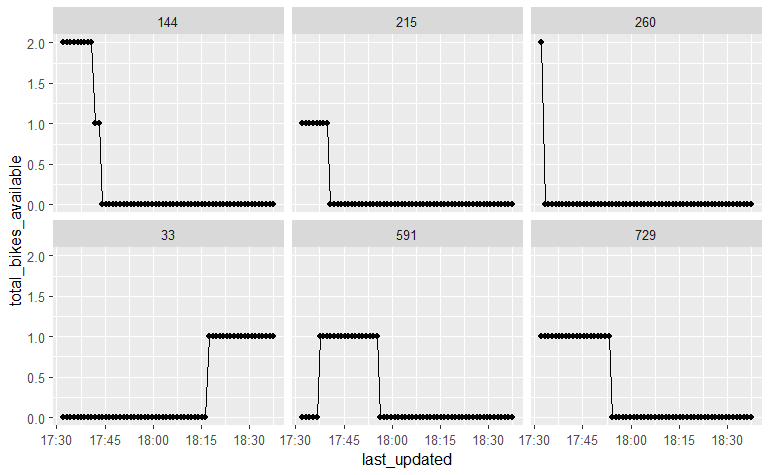

```r
avg_bikes2 = df_stations %>% group_by(station_id) %>%
  summarize(mean(total_bikes_available)) %>% clean_names() %>%
  filter(mean_total_bikes_available > 0) %>%
  slice_min(order_by = mean_total_bikes_available, n=5)

df_stations %>% filter(station_id %in% avg_bikes2$station_id) %>% ggplot(aes(last_updated, total_bikes_available)) + geom_line() + geom_point() + facet_wrap(~station_id)
```

This graph shows that there are situations where the stations will run out of bikes, and there are several stations that already had no bikes. Some of the stations are still active, unlike we thought they might be, they just did not have any bikes, such as in the case with stations 33 and 591 in this example.

We also decided to take a look specifically at when the number of ebikes run out, rather than the total amount of bikes. This lets us see if the bikes are running out proportionally, or if there is a type of bike that is taken before others. We did this very similar to how we did it with the total number of bikes available.

```r
avg_ebikes <- df_stations %>% group_by(station_id) %>% summarize(mean(num_ebikes_available)) %>% clean_names() %>% slice_min(order_by = mean_num_ebikes_available, n=5)

df_stations %>% filter(station_id %in% avg_ebikes$station_id) %>%
  filter(mean_num_ebikes_available > 0) %>% ggplot(aes(last_updated, num_ebikes_available)) + geom_line() + geom_point() + facet_wrap(~station_id, nrow = 3)
```

[output not shown]

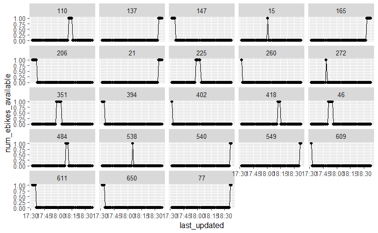

```r
avg_ebikes2 = df_stations %>% group_by(station_id) %>%
  summarize(mean(num_ebikes_available)) %>% clean_names() %>%
  filter(mean_num_ebikes_available > 0) %>%
  slice_min(order_by = mean_num_ebikes_available, n=20)

df_stations %>% filter(station_id %in% avg_ebikes2$station_id) %>% ggplot(aes(last_updated, num_ebikes_available)) + geom_line() + geom_point() + facet_wrap(~station_id)
```

A lot of the graphs show a bike being rented out almost immediately after being returned. To investigate further how long these bikes were being left at the stations before being rented again, we picked station 110 to take a closer look at.

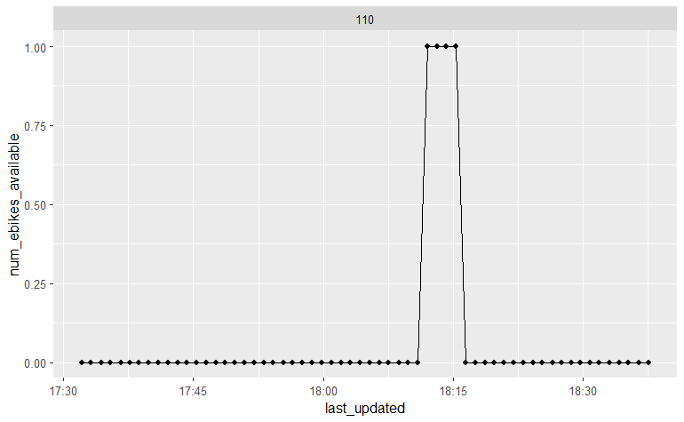

```r
avg_ebikes3 = df_stations %>% group_by(station_id) %>%
  summarize(mean(num_ebikes_available)) %>% clean_names() %>%
  filter(station_id == 110)

df_stations %>% filter(station_id %in% avg_ebikes3$station_id) %>% ggplot(aes(last_updated, num_ebikes_available)) + geom_line() + geom_point() + facet_wrap(~station_id)
```